**City College of San Francisco**

MATH 108 - Foundations of Data Science

# Lecture 25: Center and Spread

Associated Textbook Sections: [14.0, 14.1, 14.2](https://inferentialthinking.com/chapters/14/Why_the_Mean_Matters.html)

## Set Up the Notebook

```python
from datascience import *
import numpy as np
%matplotlib inline
import matplotlib.pyplot as plots
plots.style.use('fivethirtyeight')
```

# Table of Contents

## Center and Spread

### Topic Motivation

- How can we quantify natural concepts like "center" and "variability"?
- Why do many of the empirical distributions that we generate come out bell shaped?
- How is sample size related to the accuracy of an estimate?

## Average

### The Average (or Mean)

- Example
  - Data: 2, 3, 3, 9
  - Average = (2+3+3+9)/4 = 4.25
- Need not be a value in the collection
- Need not be an integer even if the data are integers
- Somewhere between min and max, but not necessarily halfway in between
- Same units as the data
- Smoothing operator: collect all the contributions in one big pot, then split evenly

### Demo: Average (Mean)

Explore various ways to calculate and interpret the average.

```python
values = make_array(2, 3, 3, 9)
```

```python
sum(values)/len(values)
```

```
4.25
```

```python
np.average(values)
```

```
4.25
```

```python
np.mean(values)
```

```
4.25
```

```python
(2 + 3 + 3 + 9)/4
```

```
4.25
```

```python
2*(1/4) + 3*(2/4) + 9*(1/4)
```

```
4.25
```

```python
values_table = Table().with_columns('value', values)
values_table
```

| value |
| --- |
| 2 |
| 3 |
| 3 |
| 9 |

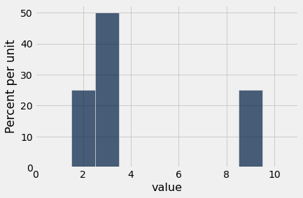

```python
bins_for_display = np.arange(0.5, 10.6, 1)
values_table.hist(0, bins = bins_for_display)
```

Let's see what happens when we increase the number of values {2, 3, 9} in the table and preserve the proportions.

```python
new_vals = make_array(2, 2, 2, 2, 2, 2, 2, 2, 2, 2,
                      3, 3, 3, 3, 3, 3, 3, 3, 3, 3, 3, 3, 3, 3, 3, 3, 3, 3, 3, 3,
                      9, 9, 9, 9, 9, 9, 9, 9, 9, 9)
```

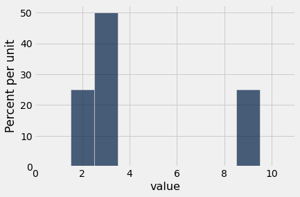

```python
Table().with_column('value', new_vals).hist(bins = bins_for_display)
```

```python
np.average(values)
```

```
4.25
```

```python
np.average(new_vals)
```

```
4.25
```

### Reflection

[figure not shown]

- Are the medians of these two distributions the same or different?
- Are the means the same or different?
- If you say "different," then say which one is bigger.

### Comparing Mean and Median

- Mean: Balance point of the histogram
- Median: Half-way point of data; half the area of histogram is on either side of median
- If the distribution is symmetric about a value, then that value is both the average and the median.
- If the histogram is skewed, then the mean is pulled away from the median in the direction of the tail.

### Reflection

[figure not shown]

Is the mean or median larger for the distribution of NBA player heights?

## Standard Deviation

### Defining Variability

- Plan A: “biggest value - smallest value”
  - Doesn’t tell us much about the shape of the distribution
- Plan B:
  - Measure variability around the mean
  - Need to figure out a way to quantify this

### Demo: Standard Deviation

Explore the standard deviation.

```python
values = make_array(2, 3, 3, 9)
```

```python
sd_table = Table().with_columns('Value', values)
sd_table
```

| Value |
| --- |
| 2 |
| 3 |
| 3 |
| 9 |

```python
average_value = np.average(sd_table.column(0))
average_value
```

```
4.25
```

```python
deviations = values - average_value
sd_table = sd_table.with_column('Deviation', deviations)
sd_table
```

| Value | Deviation |
| --- | --- |
| 2 | -2.25 |
| 3 | -1.25 |
| 3 | -1.25 |
| 9 | 4.75 |

```python
sum(deviations)
```

```
0.0
```

```python
sd_table = sd_table.with_columns('Squared Deviation', deviations ** 2)
sd_table
```

| Value | Deviation | Squared Deviation |
| --- | --- | --- |
| 2 | -2.25 | 5.0625 |
| 3 | -1.25 | 1.5625 |
| 3 | -1.25 | 1.5625 |
| 9 | 4.75 | 22.5625 |

Explore the variance of the data and see it's relationship with the standard deviation.

```python
variance = np.mean(sd_table.column('Squared Deviation'))
variance
```

```
7.6875
```

Standard Deviation (SD) is the square root of the variance

```python
sd = variance ** 0.5
sd
```

```
2.7726341266023544
```

```python
np.std(values)
```

```
2.7726341266023544
```

### How Far from the Average?

- Standard deviation (SD) measures roughly how far the data are from their average
- SD = root mean square of deviations from average
- SD has the same units as the data

### Why Use the SD?

There are two main reasons.

- No matter what the shape of the distribution, the bulk of the data are in the range "average ± a few SDs" (Chebyshev's Inequality)
- Coming up in a future lecture.